# Supplementary Material

Authors

Affiliation

Gabriel Rodrigues, MSc

Universidade Estadual de Santa Cruz

Lucas Yago Melo Ferreira, MSc

Universidade Estadual de Santa Cruz

Eric Roberto Guimarães Rocha Aguiar, PhD

Universidade Estadual de Santa Cruz

Published

October 27, 2025

Abstract

Supplementary material from the paper manusript “ViralQuest: A user-friendly interactive pipeline for viral-sequences analysis and curation”. This document provides a detailed breakdown of the parameters used in ViralQuest pipeline.

# Introduction

*ViralQuest* is a bioinformatics tool that automates the in-depth characterization of viral sequences from pre-assembled contigs. The pipeline integrates multiple lines of evidence for robust identification, using Diamond BLASTx against the Viral RefSeq database and pyHMMER searches against the RVDB, Vfam, and eggNOG profile HMM databases. For detailed characterization, ViralQuest performs taxonomic classification based on the ICTV nomenclature and functional annotation via Pfam domain analysis.

This document provides a detailed breakdown of the methods used to select the biggest non-overlapping Open Reading Frames (ORFs) in viral sequences and the parameters used to calculate the *ViralQuest* Score (VQ Score) for each contig within our bioinformatics pipeline. We employed two distinct methodologies for scoring: a qualitative assessment guided by a Large Language Model (LLM) and a quantitative, deterministic score calculated via a custom Python script. The parameters for both methods are detailed below.

# Biggest Open Reading Frame (ORF) Selection

The *ViralQuest* pipeline employs an ORF number reduction method to manage the large number of possible ORFs in a contig sequence. This process contributes to a reduction of input processing for HMM analysis via pyHMMER, consequently decreasing the overall execution time.

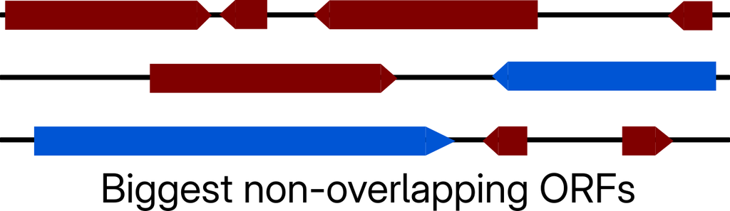

Figure 1. Visual Represantion of Biggest ORF Selection. Blue arrows represents the largest predicted ORFs of the three different frames in a sequence.

## Parameters of Biggest ORFs Selection

After analysing the RefSeq Viral Proteins database, the mean aminoacids length value of viral proteins was `~172.22 AA`. Due to that value, the Biggest ORFs Selection algorithm only selects ORFs larger than `50 AA`. This is the landscape of the length distribution of some viral proteins in the RefSeq database:

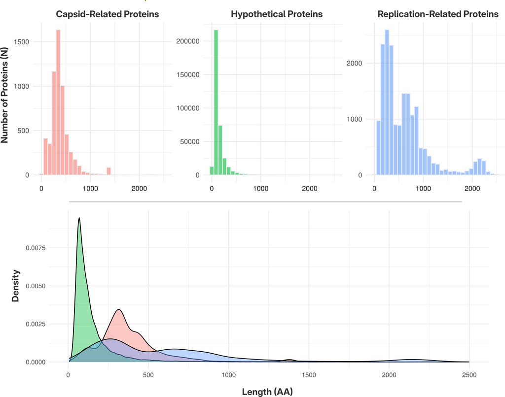

Figure 2. Distribution of Viral Proteins length in RefSeq Database (Last accessed: October 2025).

The **Capsid-related** proteins show a mean length of `~385.7 AA` (n = 5807 proteins), meanwhile the **Replication-related** proteins exhibit `~652.8 AA` (n = 18677). The **Hypothetical Proteins** group had the lowest mean amino acid length, with approximately `146.9 AA` (n = 358646).

## The Functionality of the `--maxORFs` Parameter

The parameter `--maxORFs` designates the maximum number of largest non-overlapping Open Reading Frames (ORFs) to be identified within a given sequence.

### Non-Overlapping ORF Selection

This functionality implies that the current implementation does not account for overlapping ORFs. Instead, it prioritizes the selection of the largest ORFs while enforcing a non-overlap constraint.

For instance: Consider a sequence containing two identified ORFs. The largest, **ORF A**, is 800 nucleotides (nt) long, and the second largest, **ORF B**, is 500 nt long. If the final 150 nt of **ORF B** overlaps with the initial segment of **ORF A**, the algorithm will only select the single largest non-overlapping ORF, which is **ORF A**.

### Significance of the `--maxORFs` Value

The value set for `--maxORFs` represents the upper limit for the number of non-overlapping ORFs that will be selected and reported for the sequence. If a sequence contains multiple non-overlapping ORFs that satisfy the largest-size criterion (for example, if ORF B did not overlap with ORF A), the value of `--maxORFs` must be set to a number greater than one (>1) to include these additional ORFs in the output.

This parameter is particularly relevant when analyzing the genomes of DNA or RNA viruses, which often exhibit complex and varied ORF patterns, requiring careful adjustment of the selection limit to capture the relevant coding regions. To the future versions of *ViralQuest*, our team wants to implement the detection and analysis of overlapping reading frames, probably via Machine Learning (ML) strategies, to detect the most frequent patterns of overlapping ORFs in viruses.

# Score System

## LLM-Based Score

You can use either a local LLM (via Ollama) or an API key to process and integrate viral data — such as BLAST results and HMM characterizations — with the internal ViralQuest database, which includes viral family information from ICTV (International Committee on Taxonomy of Viruses) and ViralZone. This database contains information on over 200 viral families, including details such as host range, geographic distribution, viral vectors, and more. The LLM can summarize this information to provide a broader and more insightful perspective on the viral data.

### Local LLM (via Ollama)

You can run a local LLM on your machine using Ollama. However, it is important to select a model that is well-suited for processing the data. In our tests, the smallest model that provided acceptable performance was `qwen3:8b`. Therefore, we recommend using this model as a minimum requirement for running this type of analysis.

In our tests, the use of local LLMs substancially increase the execution time of the pipeline.

### LLM Assistance via API

ViralQuest supports API-based LLMs from `Google`, `OpenAI`, and `Anthropic`, corresponding to the Gemini, ChatGPT, and Claude models, respectively. Please review the usage terms of each service, as a high number of requests in a short period (e.g., 3 to 15 requests per minute, depending on the number of viral sequences) may be subject to rate limits or usage restrictions. To avoid this kind problems, *ViralQuest* apply a 40 seconds rate limiting for API calls for each prompt input.

### LLM in ViralQuest

The arguments available to use local or API LLMs are:

```r
--model-type
    Type of model to use for analysis (ollama, openai, anthropic, google).
--model-name
    Name of the model (e.g., "qwen3:4b" for ollama, "gpt-3.5-turbo" for OpenAI).
--api-key
    API key for cloud models (required for OpenAI, Anthropic, Google).
```

This is a use of the arguments with a **Local LLM (Ollama)**:

```r
--model-type ollama --model-name "qwen3:8b"
```

Now using an **API key**:

```r
--model-type google --model-name "gemini-2.0-flash" --api-key "12345-My-API-Key_HERE67890"
```

### LLM-Based Scoring Parameters

The LLM-based score provides a holistic assessment of viral potential based on weighted criteria totaling 100 points. The model was instructed to assign scores based on the guidelines presented in Table 1.

Table 1: Scoring Criteria for the LLM-Based Methodology.

| **Criteria Definition** | **Score** |
| --- | --- |
| BLASTn Identity & Coverage (30%) |  |
| High Confidence: > 90% identity AND > 70% coverage | 25 – 30 |
| Medium Confidence: 70-90% identity AND > 50% coverage | 15 – 25 |
| Low Confidence: < 70% identity OR < 50% coverage | 8 – 15 |
| No significant data or non-viral hit | 0 – 8 |
| BLASTx Identity & Coverage (30%) |  |
| High Confidence: > 90% identity AND > 70% coverage | 25 – 30 |
| Medium Confidence: 70-90% identity AND > 50% coverage | 15 – 25 |
| Low Confidence: < 70% identity OR < 50% coverage | 0 – 15 |
| HMM Domain Detection (40%) |  |
| Strong Viral Domains (e.g., HMM score $\geq 100$) | 30 – 40 |
| Moderate Viral Domains | 20 – 30 |
| Weak or No Detectable Viral Domains | 0 – 20 |

The weights utilized in the LLM parameters (0.3, 0.3, 0.4) are proportional to the relative importance of the HMM methods used to identify viral sequences. Due to the highly divergent amino acid composition in viral proteins, identification based solely on alignment methods is limited by the high diversity inherent in viral taxonomy. Specifically, the BLASTx and BLASTn results share equal weights (0.3) in the analysis, but the HMM result is assigned a higher weight (0.4) to compensate for these limitations.

## How the LLM Process the Viral Data

The input for the VQ Score by LLM is a JSON-structurated file containing all aligments data (BLASTx and BLASTn), Viral HMM ORF conserved domains (EggNOG, RVDB and Vfam), Pfam conserved domains and their functional annotations, the complete taxonomy based on NCBI TaxID and ICTV data (Kingdom to Family, if available) and the ICTV/Viralzone viral family data relative to the matched taxonomic family.

In summary, the itens included in the JSON input for the LLM are:

- Alignments results
- Viral HMM results
- Pfam Conserved regions
- Taxonomic Classification (derived from BLASTx species identification)
- Viral Family data (based on Taxonomic Classification)

Initially the LLM processing and obtantion of ICTV/Viralzone family information was supposed to be a *Retrieval-Augmented Generation* (RAG) search in a vector database, but our tests with smaller local models (< 12 Billion parameters) showed that this method resulted in erroneus viral family information. Subsequently, the adopted strategy was to create a character-based search of the taxonomic result based on BLASTx species, to find the correspondent information in the ICTV/Viralzone item and insert it into the JSON input file.

The JSON input is embedded within a prompt, which is then used to process the information and determine the VQ Score.

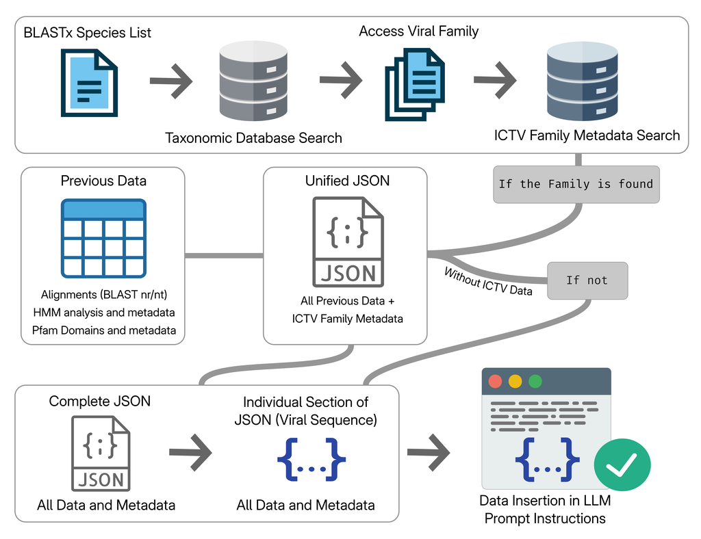

Figure 3. Data processing and acquisition to LLM-based ViralQuest Score

### JSON Input Structure

Here is an example of a JSON input with one sequence:

```json
{
  "Viral_Hits": [
    {
      "Sample_name": "SRR29420330",
      "QueryID": "SRR29420330_seq11179",
      "BLASTx_Qlength": "10703",
      "BLASTx_Slength": "3392",
      "BLASTx_Cover": "95.1",
      "BLASTx_Ident": "100.0",
      "BLASTx_evalue": "0.0",
      "BLASTx_Subject_Title": "CDF77358.1 polyprotein [dengue virus type 1]",
      "BLASTx_Organism_Name": "dengue virus type 1",
      "BLASTn_Qlength": "10703.0",
      "BLASTn_Slength": "10735.0",
      "BLASTn_Cover": "100.0",
      "BLASTn_Ident": "100.0",
      "BLASTn_evalue": "0.0",
      "BLASTn_Subject_Title": "gi|530719420|emb|HG316481.1| Dengue virus type 1 complete genome, isolate KDH0026A",
      "TaxId": "11053.0",
      "ScientificName": "dengue virus type 1",
      "NoRank": "Dengue virus",
      "Clade": "Riboviria",
      "Kingdom": "Orthornavirae",
      "Phylum": "Kitrinoviricota",
      "Class": "Flasuviricetes",
      "Order": "Amarillovirales",
      "Family": "Flaviviridae",
      "Subfamily": "",
      "Genus": "Orthoflavivirus",
      "Species": "Orthoflavivirus denguei",
      "Genome": "ssRNA(+)",
      "vq_score": "100"
    }
  ],
  "HMM_hits": [
    {
      "Sample_name": "SRR29420330",
      "Query_name": "SRR29420330_seq11179_ORF.2",
      "QueryID": "SRR29420330_seq11179",
      "RVDB_TargetID": "FAM000221",
      "RVDB_Description": "Flaviviridae",
      "RVDB_Score": "6385.26",
      "RVDB_Start": "1.0",
      "RVDB_End": "3393.0",
      "RVDB_length": "3392.0",
      "Vfam_TargetID": "VFAM07664",
      "Vfam_Description": "sp-P33515-POLG-MCFA Genome polyprotein",
      "Vfam_Score": "642.89",
      "Vfam_Start": "283.0",
      "Vfam_End": "776.0",
      "Vfam_length": "493.0",
      "EggNOG_TargetID": "ENOG411ENT5",
      "EggNOG_Description": "ssRNA_positive - FtsJ-like methyltransferase",
      "EggNOG_Score": "1852.35",
      "EggNOG_Start": "2495.0",
      "EggNOG_End": "3393.0",
      "EggNOG_length": "898.0",
      "Pfam_Accession": "PF01003",
      "Pfam_Description": "Flavivirus capsid protein C",
      "Pfam_Info": "<p>Flaviviruses are small enveloped viruses with v...",
      "Pfam_Type": "Family",
      "Pfam_Score": "112.95",
      "Pfam_Start": "6.0",
      "Pfam_End": "118.0",
      "Pfam_length": "112.0",
      "FullSequence": "LMNNQRKKTARPSFNMLKRARNRVSTVPQLA...",
      "Pfam_Accession_2": "PF01570",
      "Pfam_Description_2": "Flavivirus polyprotein propeptide",
      "Pfam_Info_2": "<p>The flaviviruses are small enveloped animal viruses containing a single...",
      "Pfam_Type_2": "Family",
      "Pfam_Score_2": "153.33926391601562",
      "Pfam_Start_2": "121.0",
      "Pfam_End_2": "205.0",
      "Pfam_length_2": "84.0",
      "Pfam_Accession_3": "PF01004",
      "Pfam_Description_3": "Flavivirus envelope glycoprotein M",
      "Pfam_Info_3": "<p>Flaviviruses are small enveloped viruses with virions...",
      "Pfam_Type_3": "Family",
      "Pfam_Score_3": "125.5305633544922",
      "Pfam_Start_3": "208.0",
      "Pfam_End_3": "281.0",
      "Pfam_length_3": "73.0",
      "Pfam_Accession_4": "PF00869",
      "Pfam_Description_4": "Flavivirus glycoprotein, central and dimerisation domains",
      "Pfam_Info_4": "",
      "Pfam_Type_4": "Domain",
      "Pfam_Score_4": "568.2359008789062",
      "Pfam_Start_4": "283.0",
      "Pfam_End_4": "577.0",
      "Pfam_length_4": "294.0",
      "Pfam_Accession_5": "PF02832",
      "Pfam_Description_5": "Flavivirus glycoprotein, immunoglobulin-like domain",
      "Pfam_Info_5": "",
      "Pfam_Type_5": "Domain",
      "Pfam_Score_5": "169.0703887939453",
      "Pfam_Start_5": "579.0",
      "Pfam_End_5": "674.0",
      "Pfam_length_5": "95.0",
      "Pfam_Accession_6": "PF01349",
      "Pfam_Description_6": "Flavivirus non-structural protein NS4B",
      "Pfam_Info_6": "<p>Flaviviruses encode a single polyprotein...",
      "Pfam_Type_6": "Family",
      "Pfam_Score_6": "451.3087463378906",
      "Pfam_Start_6": "729.0",
      "Pfam_End_6": "775.0",
      "Pfam_length_6": "46.0",
      "Pfam_Accession_7": "PF00948",
      "Pfam_Description_7": "Flavivirus non-structural Protein NS1",
      "Pfam_Info_7": "<p>The NS1 protein is well conserved amongst the flaviviruses. It contain...",
      "Pfam_Type_7": "Family",
      "Pfam_Score_7": "714.5770263671875",
      "Pfam_Start_7": "778.0",
      "Pfam_End_7": "1131.0",
      "Pfam_length_7": "353.0",
      "Pfam_Accession_8": "PF01005",
      "Pfam_Description_8": "Flavivirus non-structural protein NS2A",
      "Pfam_Info_8": "<p>NS2A is a hydrophobic protein about 25 kDa is size...",
      "Pfam_Type_8": "Family",
      "Pfam_Score_8": "298.9154663085937",
      "Pfam_Start_8": "1139.0",
      "Pfam_End_8": "1325.0",
      "Pfam_length_8": "186.0",
      "Pfam_Accession_9": "PF01002",
      "Pfam_Description_9": "Flavivirus non-structural protein NS2B",
      "Pfam_Info_9": "<p>Flaviviruses encode a single polyprotein. This is cleaved...",
      "Pfam_Type_9": "Family",
      "Pfam_Score_9": "225.1991577148437",
      "Pfam_Start_9": "1350.0",
      "Pfam_End_9": "1476.0",
      "Pfam_length_9": "126.0",
      "Pfam_Accession_10": "PF07652",
      "Pfam_Description_10": "Flavivirus DEAD domain",
      "Pfam_Info_10": "",
      "Pfam_Type_10": "Domain",
      "Pfam_Score_10": "244.12469482421875",
      "Pfam_Start_10": "1660.0",
      "Pfam_End_10": "1807.0",
      "Pfam_length_10": "147.0",
      "Pfam_Accession_11": "PF13625",
      "Pfam_Description_11": "Helicase conserved C-terminal domain",
      "Pfam_Info_11": "<p>This domain family is found in a wide variety of helicases and helicase-related proteins.</p>",
      "Pfam_Type_11": "Domain",
      "Pfam_Score_11": "21.694320678710938",
      "Pfam_Start_11": "1825.0",
      "Pfam_End_11": "1942.0",
      "Pfam_length_11": "117.0",
      "Pfam_Accession_12": "PF20907",
      "Pfam_Description_12": "Flavivirus NS3 helicase, C-terminal helical domain",
      "Pfam_Info_12": "<p>This domain is found at the C-terminal end of NS3 helicase...",
      "Pfam_Type_12": "Domain",
      "Pfam_Score_12": "236.89268493652344",
      "Pfam_Start_12": "1951.0",
      "Pfam_End_12": "2093.0",
      "Pfam_length_12": "142.0",
      "Pfam_Accession_13": "PF01350",
      "Pfam_Description_13": "Flavivirus non-structural protein NS4A",
      "Pfam_Info_13": "<p>Flaviviruses encode a single polyprotein. This is cleaved...",
      "Pfam_Type_13": "Family",
      "Pfam_Score_13": "256.4847106933594",
      "Pfam_Start_13": "2100.0",
      "Pfam_End_13": "2243.0",
      "Pfam_length_13": "143.0",
      "Pfam_Accession_14": "PF01349",
      "Pfam_Description_14": "Flavivirus non-structural protein NS4B",
      "Pfam_Info_14": "<p>Flaviviruses encode a single polyprotein...",
      "Pfam_Type_14": "Family",
      "Pfam_Score_14": "451.3087463378906",
      "Pfam_Start_14": "2246.0",
      "Pfam_End_14": "2487.0",
      "Pfam_length_14": "241.0",
      "Pfam_Accession_15": "PF01728",
      "Pfam_Description_15": "FtsJ-like methyltransferase",
      "Pfam_Info_15": "<p>This family consists of FtsJ from various bacterial...",
      "Pfam_Type_15": "Family",
      "Pfam_Score_15": "73.91443634033203",
      "Pfam_Start_15": "2548.0",
      "Pfam_End_15": "2718.0",
      "Pfam_length_15": "170.0",
      "Pfam_Accession_16": "PF00972",
      "Pfam_Description_16": "Flavivirus RNA-directed RNA polymerase, fingers and palm domains",
      "Pfam_Info_16": "<p>Flaviviruses produce a large polyprotein from the ssRNA genome...",
      "Pfam_Type_16": "Domain",
      "Pfam_Score_16": "922.4544677734376",
      "Pfam_Start_16": "2744.0",
      "Pfam_End_16": "3193.0",
      "Pfam_length_16": "449.0",
      "Pfam_Accession_17": "PF20483",
      "Pfam_Description_17": "Flavivirus RNA-directed RNA polymerase, thumb domain",
      "Pfam_Info_17": "<p>Flaviviruses produce a large polyprotein from the ssRNA genome...",
      "Pfam_Type_17": "Domain",
      "Pfam_Score_17": "262.0962219238281",
      "Pfam_Start_17": "3197.0",
      "Pfam_End_17": "3360.0",
      "Pfam_length_17": "163.0"
    }
  ]
}
```

The `vq_score` in the JSON is from a previous Rule-Based Score, that will be replaced by the LLM-Based Score.

## LLM Prompt Structure

The LLM prompt follow two diffrent structuries, one for **Langchain** API modules and another for **Ollama** local LLMs. The Langchain template contain all informations in one single prompt, while Ollama employ a system prompt instruction and an user input prompt.

The `{sequence_data}` variable is the individual section of JSON input, as shown in **Figure 3**. Viral family information of ICTV/Viralzone is embedded in `{taxonomy_info}`. In case of absense of viral family informartion, another prompt is used without the `{taxonomy_info}` variable

### Langchain Prompt

This is the **Langchain** template with viral family information.

```r
langchain_template = """
    You are a virology expert analyzing potential viral sequences from bioinformatics data. Be skeptical in your analysis.

    ## Input Data:
    - BLASTx and BLASTn hits with organism taxonomy
    - HMMER hits (RVDB, Vfam, eggNOG, Pfam)
    - Viral taxonomy information (order/family/genus)

    Sequence data:
    "{sequence_data}"

    Taxonomy info:
    "{taxonomy_info}"

    ## Required Outputs:

    ### 1. Text Analysis (max 200 words)
    Analyze taxonomy, host range, geographic circulation, and classify as:
    - Known virus (>90% identity + >70% coverage)
    - Novel virus
    - Non-viral sequence
    Include demarcation criteria for the taxonomic group.

    ### 2. VQ_SCORE (0-100)
    Calculate based on weighted criteria:

    **BLASTn identity/coverage (30%)**
    - >90% identity + >70% coverage = 25-30 pts
    - 70-90% identity + >50% coverage = 15-25 pts
    - <70% identity or <50% coverage = 8-15 pts
    - No data/non-viral hit = 0-8 pts

    **BLASTx identity/coverage (30%)**
    - >90% identity + >70% coverage = 25-30 pts
    - 70-90% identity + >50% coverage = 15-25 pts
    - <70% identity or <50% coverage = 0-15 pts

    **HMM domain detection (40%)**
    - Strong viral domains (score >100) = 30-40 pts
    - Moderate viral domains = 20-30 pts
    - Weak/no domains = 0-20 pts

    **Score interpretation:**
    - 90-100: Known viral sequences
    - 70-90: High confidence viral
    - 50-70: Likely novel viruses
    - 30-50: Low information
    - 0-30: Low viral probability

    ## Format Requirements:
    1. Maximum 200 words for the text analysis
    2. Plain text only for analysis
    3. No introduction, greeting, or personal commentary
    4. No reference to prompt or question
    5. Avoid using Markdown header elements in the text
    8. Don't provide any reference about VQ SCORE calculation in the text
    9. Handle missing data gracefully

    ## Example Output:
    [TEXT_ANALYSIS]
    The sequence shows 95% amino acid identity to Hepatitis B virus polymerase with 85% coverage
    via BLASTx. HMMER detected strong viral replication domains (score 150). This represents a
    known HBV strain with typical host range in humans and circulation in Asia-Pacific regions.
    Hepadnaviridae demarcation requires >80% nucleotide identity for species classification.
    [/TEXT_ANALYSIS]

    [VQ_SCORE]
    92
    [/VQ_SCORE]

    ## CRITICAL FORMATTING REQUIREMENTS:
    - The VQ_SCORE must be a plain integer between 0-100 with NO quotes, NO decimals, NO additional text
    - WRONG formats: [VQ_SCORE]'85'[/VQ_SCORE] or [VQ_SCORE]85.0[/VQ_SCORE] or [VQ_SCORE]about 85[/VQ_SCORE]
"""
```

### Ollama Prompt

This is the **Ollama** template with viral family information.

*System Prompt*

```r
ollama_system_prompt = """
    You are a virology expert analyzing potential viral sequences from bioinformatics data. Be skeptical in your analysis.

    ## Input Data:
    - BLASTx and BLASTn hits with organism taxonomy
    - HMMER hits (RVDB, Vfam, eggNOG, Pfam)
    - Viral taxonomy information (order/family/genus)

    ## Required Outputs:

    ### 1. Text Analysis (max 200 words)
    Analyze taxonomy, host range, geographic circulation, and classify as:
    - Known virus (>90% identity + >70% coverage)
    - Novel virus
    - Non-viral sequence
    Include demarcation criteria for the taxonomic group.

    ### 2. VQ_SCORE (0-100)
    Calculate based on weighted criteria:

    **BLASTn identity/coverage (30%)**
    - >90% identity + >70% coverage = 25-30 pts
    - 70-90% identity + >50% coverage = 15-25 pts
    - <70% identity or <50% coverage = 8-15 pts
    - No data/non-viral hit = 0-8 pts

    **BLASTx identity/coverage (30%)**
    - >90% identity + >70% coverage = 25-30 pts
    - 70-90% identity + >50% coverage = 15-25 pts
    - <70% identity or <50% coverage = 0-15 pts

    **HMM domain detection (40%)**
    - Strong viral domains (score >100) = 30-40 pts
    - Moderate viral domains = 20-30 pts
    - Weak/no domains = 0-20 pts

    **Score interpretation:**
    - 90-100: Known viral sequences
    - 70-90: High confidence viral
    - 50-70: Likely novel viruses
    - 30-50: Low information
    - 0-30: Low viral probability

    ## Format Requirements:
    1. Maximum 200 words for the text analysis
    2. Plain text only for analysis
    3. No introduction, greeting, or personal commentary
    4. No reference to prompt or question
    ## CRITICAL FORMATTING REQUIREMENTS:
    - The VQ_SCORE must be a plain integer between 0-100 with NO quotes, NO decimals, NO additional text
    - WRONG formats: [VQ_SCORE]'85'[/VQ_SCORE] or [VQ_SCORE]85.0[/VQ_SCORE] or [VQ_SCORE]about 85[/VQ_SCORE]
    - Don't write any reference of [VQ_SCORE] in [TEXT_ANALYSIS] section.

    5. Avoid using Markdown header elements in the text
    8. Don't provide any reference about VQ SCORE calculation in the text
    9. Handle missing data gracefully

    ## Example Output:
    [TEXT_ANALYSIS]
    The sequence shows 95% amino acid identity to Hepatitis B virus polymerase with 85% coverage
    via BLASTx. HMMER detected strong viral replication domains (score 150). This represents a
    known HBV strain with typical host range in humans and circulation in Asia-Pacific regions.
    Hepadnaviridae demarcation requires >80% nucleotide identity for species classification.
    [/TEXT_ANALYSIS]

    [VQ_SCORE]
    92
    [/VQ_SCORE]

    ## CRITICAL FORMATTING REQUIREMENTS:
    - The VQ_SCORE must be a plain integer between 0-100 with NO quotes, NO decimals, NO additional text
    - WRONG formats: [VQ_SCORE]'85'[/VQ_SCORE] or [VQ_SCORE]85.0[/VQ_SCORE] or [VQ_SCORE]about 85[/VQ_SCORE]
    - Don't write any reference of [VQ_SCORE] in [TEXT_ANALYSIS] section.

"""
```

*User Prompt*

```r
ollama_user_prompt_template = """
    Sequence data:
    "{sequence_data}"

    Taxonomy info:
    "{taxonomy_info}"
"""
```